# DistortionSphere QML Type

A sphere distortion effect. More...

| Import Statement: | `import QtQuick3D.Effects 6.9` |
| --- | --- |
| Status: | Deprecated since 6.5 |

**This type is deprecated since QtQuick3D.Effects 6.5. We strongly advise against using it in new code.**

- [List of all members, including inherited members](https://doc.qt.io/qt-6.9/qml-qtquick3d-effects-distortionsphere-members.html)

## Properties

- **center** : vector2d
- **distortionHeight** : real
- **radius** : real

## Detailed Description

Use ExtendedSceneEnvironment, MultiEffect, or user-defined effects via the Effect type instead.

**Warning:** All pre-made standalone effects in [QtQuick3D](https://doc.qt.io/qt-6.9/qtquick3d-qmlmodule.html).Effects are considered deprecated starting with Qt 6.5. Applications are advised to use ExtendedSceneEnvironment or MultiEffect instead, when applicable, or alternatively provide their own custom post-processing effect via the Effect type.

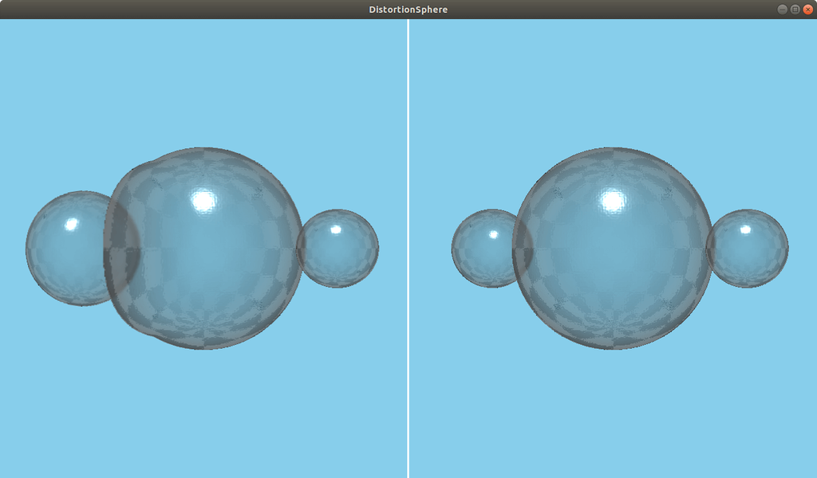

The DistortionSphere effect creates a 3D effect of wrapping the scene around a spherical shape.

## Property Documentation

### center : vector2d

The center point of the distortion. The default is `Qt.vector2d(0.5, 0.5)`, the center of the scene.

### distortionHeight : real

The distortion amount. The range is `[-1...1]`, where positive values distort towards the camera, and negative values distort away from the camera. The default value is `0.5`.

### radius : real

How far the distortion extends from the center point. The range is `[0...1]`. The default value is `0.25`.

© The Qt Company Ltd  
Licensed under the GNU Free Documentation License, Version 1.3.  
https://doc.qt.io/qt-6.9/qml-qtquick3d-effects-distortionsphere.html